# Explore NEON LiDAR Data

sjmc

June 9, 2016

### Short Bio

Hi, I’m a Ph.D. student and participant at the 2016 NEON Data Institute. **Forest ecology** is my jam. Much of my research looks at how organisms and ecosystems respond to stress, such as drought and air pollution. I’m also interested in what goes on in ecosystems after disturbances. I work at the University of California Berkeley, and my field studies are in the Sierra Nevada. My full bio is available [here.](https://en.wikipedia.org/wiki/Triceratops)

### About My Workshop Project

- I’m interested in investigating how a disturbance - detected with hyperspectral veg data or simply known from ground measurements - is reflected in CO2 or other fluxes.
  - Hoping to work w/ data from the Pacific Southwest or Pacific Northwest domains, and am especially interested in Teakettle, though I know it is still getting up and running.
  - Data needed may include:
    - hyperspectral vegetation data
    - standardized forest structure measurements (DBH, height, maybe biomass)
    - fluxes for pre- and post- event
    - (External) disturbance event information, such as a fire or mortality event.
  - In the process, I’m also interested in quantifying uncertainties when combining vegetation plots or LiDAR w/ remotely sensed data.

### Week 3 Activity

- This page is a demo of a few NEON LiDAR products using Teakettle Experimental Forest as an example
  - And, practice using **RMarkdown**

##### 1. First, let’s get set up:

```r
  #load libraries
    library(rgdal)
    library(raster)
   # set working directory to ensure R can find the file we wish to import
   setwd("/Users/stellac/Documents/HomeWork/data/NEONDI-2016/")
```

- Note that in order to knit properly, your .md file (this document) should be saved in that same wd. At least, that seems to be what the knittr documentation says.

##### 2. Load the Teakettle elevation raster:

```r
   # import dsm
    teak_dsm <- raster("NEONdata/D17-California/TEAK/2013/lidar/TEAK_lidarDSM.tif" )
```

##### 3. View the Teakettle elevation raster (digital surface model):

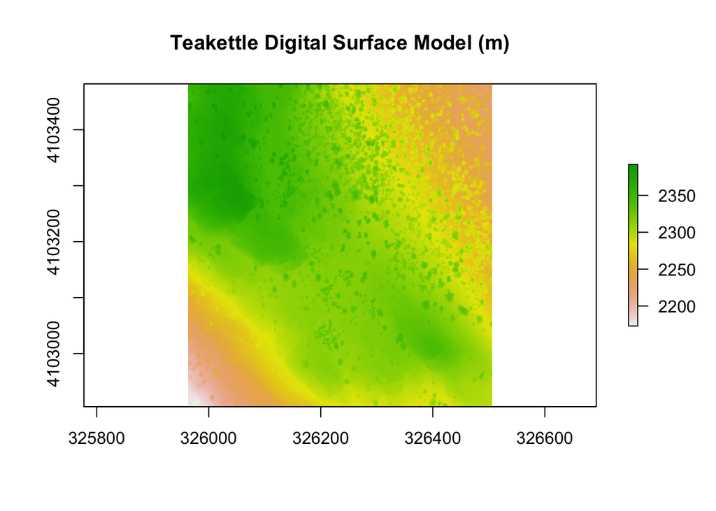

```r
   # plot it up flat
   plot(teak_dsm, main= "Teakettle Digital Surface Model (m)")
```

- Observations: looks like a ridgetop in the upper left. At this elevation, could be bare granite.
- High points are probably trees.

##### 4. View that surface model as a histogram:

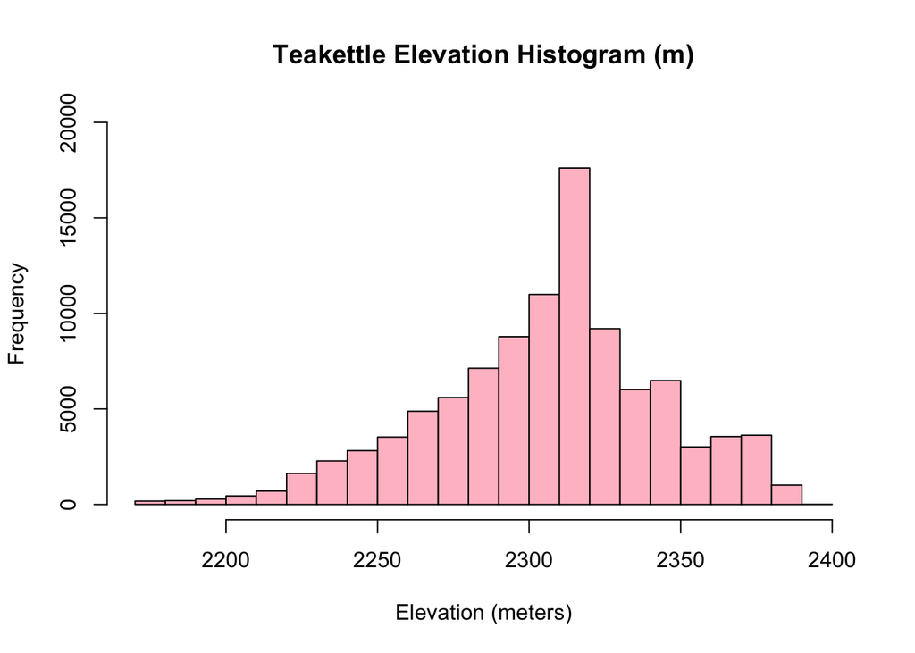

```r
   # plot it up histogram
   hist(teak_dsm,breaks=20,col="pink",ylim = c(0,20000),main = "Teakettle Elevation Histogram (m)",xlab = "Elevation (meters)",ylab="Frequency")
```

##### 5. Load the Teakettle LiDAR-derived canopy height model:

```r
   # import CHM
   teak_CHM <- raster("NEONdata/D17-California/TEAK/2013/lidar/TEAK_lidarCHM.tif" )
```

##### 6. View the Teakettle LiDAR-derived canopy height model:

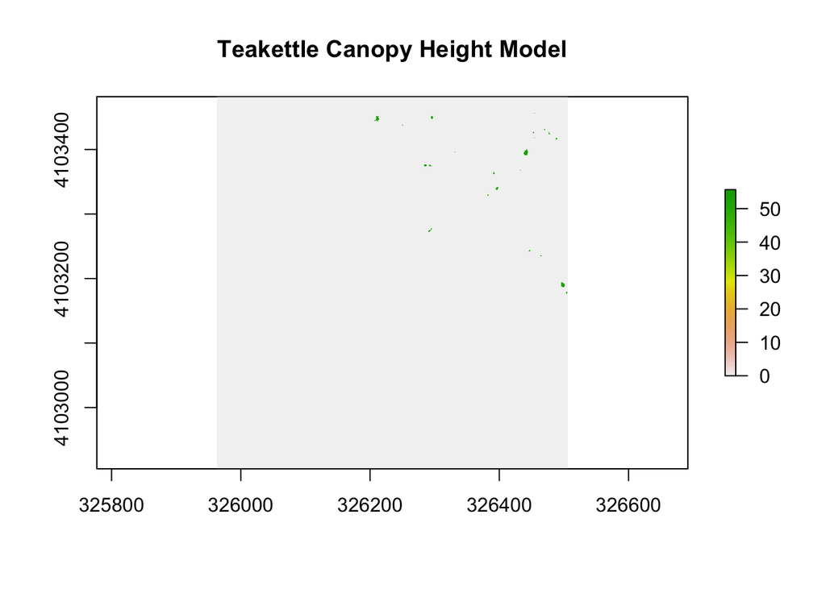

```r
   # plot it up flat
#note to self : tried it w/ this added, but still just a few specks
#breaks = c(seq(0,70,by=5)), col=terrain.colors(14))
   plot(teak_CHM, main= "Teakettle Canopy Height Model")
```

- Observations: seems like this might be a location w/ very few mature trees? Not sure how to interpret this, I’d expect a dense forest - especially based on the DSM. Not a very large area, though.

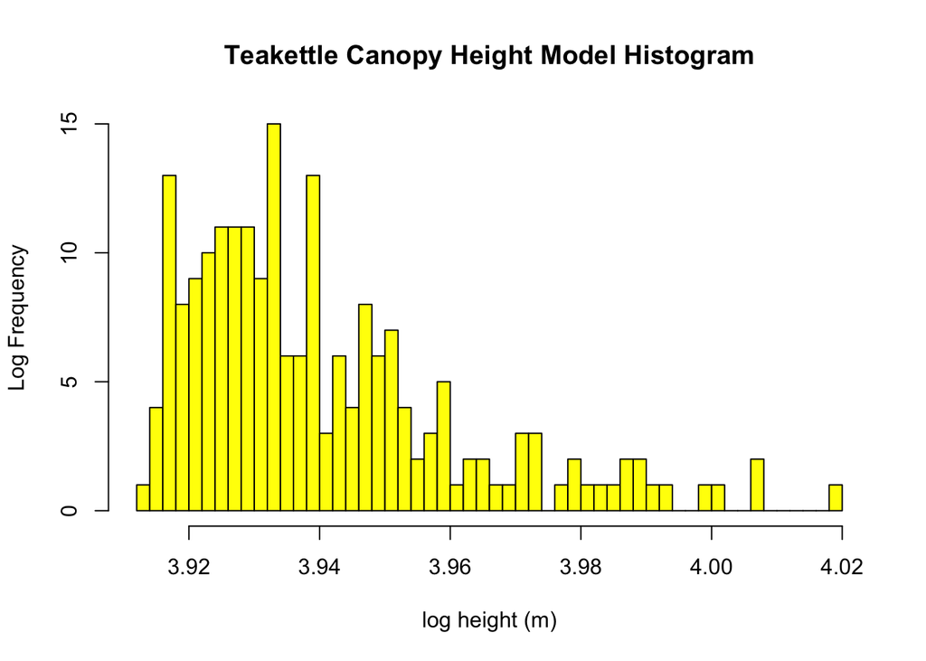

```r
   # plot it up histogram-wise
   #log scale to see detail/variation
   hist(log(teak_CHM), breaks=50,col="yellow",main = "Teakettle Canopy Height Model Histogram",ylab = "Log Frequency", xlab = "log height (m)")
```

- that’s all for now!